# R Tutorial: forcats package

Philipp Leppert

17.12.2021

Reading time: 13 minutes (2,427 words)

## 1. Introduction

In this tutorial I’ll show you how to handle categorical variables (**factors**) with the package `forcats`. Factors represent another storage type for columns like *character* or *numeric*. The behavior of factors in R is not always consistent, especially when switching between conventional *data frames* and *tibbles* (for more information about the difference see [this tutorial](https://rpubs.com/phle/r-tutorial-tibble)). There is an interesting [article](https://simplystatistics.org/posts/2015-07-24-stringsasfactors-an-unauthorized-biography/) by Roger Peng who explains factors in the course of R’s development.

For this tutorial you’ll **need to know** some functions of the `dplyr` package like `mutate()`, `summarise()` and `group_by()`. So I recommend you briefly read the sections 2 to 6 of [this tutorial](https://rpubs.com/phle/r-tutorial-dplyr) first.

Otherwise load both packages.

```r
library(forcats)
library(dplyr)
library(tibble)
```

We will work once more with the `starwars` dataset conainted in the `dplyr` package. Below let’s have a `tibble::glimpse()` at the dataset.

```r
starwars %>%
  glimpse()
```

```
## Rows: 87
## Columns: 14
## $ name       <chr> "Luke Skywalker", "C-3PO", "R2-D2", "Darth Vader", "Leia Or~
## $ height     <int> 172, 167, 96, 202, 150, 178, 165, 97, 183, 182, 188, 180, 2~
## $ mass       <dbl> 77.0, 75.0, 32.0, 136.0, 49.0, 120.0, 75.0, 32.0, 84.0, 77.~
## $ hair_color <chr> "blond", NA, NA, "none", "brown", "brown, grey", "brown", N~
## $ skin_color <chr> "fair", "gold", "white, blue", "white", "light", "light", "~
## $ eye_color  <chr> "blue", "yellow", "red", "yellow", "brown", "blue", "blue",~
## $ birth_year <dbl> 19.0, 112.0, 33.0, 41.9, 19.0, 52.0, 47.0, NA, 24.0, 57.0, ~
## $ sex        <chr> "male", "none", "none", "male", "female", "male", "female",~
## $ gender     <chr> "masculine", "masculine", "masculine", "masculine", "femini~
## $ homeworld  <chr> "Tatooine", "Tatooine", "Naboo", "Tatooine", "Alderaan", "T~
## $ species    <chr> "Human", "Droid", "Droid", "Human", "Human", "Human", "Huma~
## $ films      <list> <"The Empire Strikes Back", "Revenge of the Sith", "Return~
## $ vehicles   <list> <"Snowspeeder", "Imperial Speeder Bike">, <>, <>, <>, "Imp~
## $ starships  <list> <"X-wing", "Imperial shuttle">, <>, <>, "TIE Advanced x1",~
```

There are columns of type character *(chr)*, numeric *(int, dbl)*, and *list*. Do you have an idea which columns are suitable to be treated as factors?

## 2. Factors

A factor is R’s data structure for categorical data and the `forcats` package provides many functions to work with them. Factors are often required when performing regression analysis in R with `lm()` or `glm()`. These functions need factors to handle categorical data appropriately. For example R maps the unique values of a categorical variable to individual dummy variables in order to estimate the regression model. Therefore it’s good to know for a start about some basic functions that handle categorical data.

### 2.1 General

The following functions are used for basic operations on factors.

#### factor()

With this function we can create a new *factor* variable from scratch. First we have to input a vector `x =` of values and then a vector of `levels =`.

```r
factor(
  x = c("1", "2", "3",
        "1", "2", "3"),
  levels = c("1", "2", "3")
  )
```

```
## [1] 1 2 3 1 2 3
## Levels: 1 2 3
```

Below the values of the factor we see a line with its levels.

There is also a `label =` argument where we can supply labels for the factor levels. By default the labels are identical to the levels. The labels have to appear in the same order as the levels.

```r
factor(
  x = c("1", "2", "3",
        "1", "2", "3"),
  levels = c("1", "2", "3"),
  labels = c("first", "second", "third")
  )
```

```
## [1] first  second third  first  second third
## Levels: first second third
```

#### as.factor()

We may also take an already existing column of the `starwars` dataset and transform it with function `as.factor()` and `dplyr::mutate()` into a *factor* variable. Below I take the `species` variable and convert it to a factor. Only the storage type of the column is altered but not the values of `species`.

```r
starwars %>%
  mutate(species_fct = as.factor(species)) %>%
  select(name, starts_with("species"))
```

```
## # A tibble: 87 x 3
##    name               species species_fct
##    <chr>              <chr>   <fct>
##  1 Luke Skywalker     Human   Human
##  2 C-3PO              Droid   Droid
##  3 R2-D2              Droid   Droid
##  4 Darth Vader        Human   Human
##  5 Leia Organa        Human   Human
##  6 Owen Lars          Human   Human
##  7 Beru Whitesun lars Human   Human
##  8 R5-D4              Droid   Droid
##  9 Biggs Darklighter  Human   Human
## 10 Obi-Wan Kenobi     Human   Human
## # ... with 77 more rows
```

#### levels()

The function `levels()` creates a vector of all *unique* values of a factor. It is important that the column on which this function is applied to is a **vector and a factor**. First, let us take a look what happens if we use `levels()` on a column that is *not* of type factor.

```r
starwars %>%
  pull(species) %>%
  levels()
```

[output not shown]

It simply returns `NULL` because there are no levels attached to the column `species` which is originally of type character. Next we’ll try `levels()` on the converted `species_fct` column.

```r
starwars %>%
  mutate(species_fct = as.factor(species)) %>%
  pull(species_fct) %>%
  levels()
```

```
##  [1] "Aleena"         "Besalisk"       "Cerean"         "Chagrian"
##  [5] "Clawdite"       "Droid"          "Dug"            "Ewok"
##  [9] "Geonosian"      "Gungan"         "Human"          "Hutt"
## [13] "Iktotchi"       "Kaleesh"        "Kaminoan"       "Kel Dor"
## [17] "Mirialan"       "Mon Calamari"   "Muun"           "Nautolan"
## [21] "Neimodian"      "Pau'an"         "Quermian"       "Rodian"
## [25] "Skakoan"        "Sullustan"      "Tholothian"     "Togruta"
## [29] "Toong"          "Toydarian"      "Trandoshan"     "Twi'lek"
## [33] "Vulptereen"     "Wookiee"        "Xexto"          "Yoda's species"
## [37] "Zabrak"
```

This worked as expected! Anybody remember the function `dplyr::distinct()` from the [dplyr tutorial](https://rpubs.com/phle/r-tutorial-dplyr)? This functions also lists all unique values of a column but can be applied to *any* column type.

```r
starwars %>%
  distinct(species)
```

```
## # A tibble: 38 x 1
##    species
##    <chr>
##  1 Human
##  2 Droid
##  3 Wookiee
##  4 Rodian
##  5 Hutt
##  6 Yoda's species
##  7 Trandoshan
##  8 Mon Calamari
##  9 Ewok
## 10 Sullustan
## # ... with 28 more rows
```

There is also a minor difference: `distinct()` lists `NA` as a unique value while `levels()` does not. However, using function `factor()` with argument `exclude = NULL` retains `NA` in the output.

```r
starwars %>%
  mutate(species_fct = factor(species, exclude = NULL)) %>%
  pull(species_fct) %>%
  levels()
```

```
##  [1] "Aleena"         "Besalisk"       "Cerean"         "Chagrian"
##  [5] "Clawdite"       "Droid"          "Dug"            "Ewok"
##  [9] "Geonosian"      "Gungan"         "Human"          "Hutt"
## [13] "Iktotchi"       "Kaleesh"        "Kaminoan"       "Kel Dor"
## [17] "Mirialan"       "Mon Calamari"   "Muun"           "Nautolan"
## [21] "Neimodian"      "Pau'an"         "Quermian"       "Rodian"
## [25] "Skakoan"        "Sullustan"      "Tholothian"     "Togruta"
## [29] "Toong"          "Toydarian"      "Trandoshan"     "Twi'lek"
## [33] "Vulptereen"     "Wookiee"        "Xexto"          "Yoda's species"
## [37] "Zabrak"         NA
```

### 2.2 Inspect

The following functions are used to have a closer look at the values and levels of a factor.

#### fct_count()

With `fct_count()` you’re able to count the number of values for each level of a factor variable. Below I apply this to the `species` column of the `starwars` dataset.

```r
fct_count(starwars$species)
```

```
## # A tibble: 38 x 2
##    f             n
##    <fct>     <int>
##  1 Aleena        1
##  2 Besalisk      1
##  3 Cerean        1
##  4 Chagrian      1
##  5 Clawdite      1
##  6 Droid         6
##  7 Dug           1
##  8 Ewok          1
##  9 Geonosian     1
## 10 Gungan        3
## # ... with 28 more rows
```

Note that it is not always necessary to convert columns of type *character* to a factor before applying functions of the `forcats` package.

By the way: the function `dplyr::count()` returns a similar output.

```r
starwars %>%
  count(species)
```

```
## # A tibble: 38 x 2
##    species       n
##    <chr>     <int>
##  1 Aleena        1
##  2 Besalisk      1
##  3 Cerean        1
##  4 Chagrian      1
##  5 Clawdite      1
##  6 Droid         6
##  7 Dug           1
##  8 Ewok          1
##  9 Geonosian     1
## 10 Gungan        3
## # ... with 28 more rows
```

#### fct_match()

We can check for the presence of any level in a factor with the function `fct_match()`. It simply returns `TRUE` if a level is present or `FALSE` if it is not. Let’s see whether any values of the factor `sex` display a level `"male"`.

```r
fct_match(starwars$sex, "male") %>% table()
```

```
## .
## FALSE  TRUE
##    27    60
```

There are 60 Star Wars characters where the level `"male"` is present.

We may also check multiple levels at once.

```r
fct_match(starwars$sex, c("male", "female")) %>% table()
```

```
## .
## FALSE  TRUE
##    11    76
```

There are 76 Star Wars characters with either a `"male"` or `"female"` level of factor `sex`.

#### fct_unique()

The function `fct_unique()` only returns the unique values of a *factor* and removes duplicates.

```r
fct_unique(starwars_fct$sex)
```

```
## [1] female         hermaphroditic male           none
## Levels: female hermaphroditic male none
```

### 2.3 Combine

We may also combine different factors with the following functions.

#### fct_c()

With function `fct_c()` we can combine factors with *different levels*. Below I create two factors `f1` and `f2` which represent the `sex` and `gender` column of the `starwars` dataset. Then I use `fct_c()` to combine them.

```r
f1 <- as.factor(starwars$sex)
f2 <- as.factor(starwars$gender)

fct_c(f1, f2) %>% levels()
```

```
## [1] "female"         "hermaphroditic" "male"           "none"
## [5] "feminine"       "masculine"
```

This function is best used to patch together factors from multiple sources that should have the same levels.

There is also a neat function called `fct_cross()` which computes a factor whose levels are the combinations of the levels of all input factors.

```r
starwars %>%
  mutate(sex_gender = fct_cross(sex, gender)) %>%
  select(name, sex_gender, sex, gender)
```

```
## # A tibble: 87 x 4
##    name               sex_gender      sex    gender
##    <chr>              <fct>           <chr>  <chr>
##  1 Luke Skywalker     male:masculine  male   masculine
##  2 C-3PO              none:masculine  none   masculine
##  3 R2-D2              none:masculine  none   masculine
##  4 Darth Vader        male:masculine  male   masculine
##  5 Leia Organa        female:feminine female feminine
##  6 Owen Lars          male:masculine  male   masculine
##  7 Beru Whitesun lars female:feminine female feminine
##  8 R5-D4              none:masculine  none   masculine
##  9 Biggs Darklighter  male:masculine  male   masculine
## 10 Obi-Wan Kenobi     male:masculine  male   masculine
## # ... with 77 more rows
```

#### fct_unify()

For standardizing the levels across a *list of factors* we can use the function `fct_unify()`. It returns a list where each element is the initial factor augmented by the unified levels. To see only the `levels()` of each factor we have to apply a special function called `map()` from the package `purrr`. It applies the functions `levels()` to each list element. Read more about it here.

```r
f3 <- as.factor(starwars$eye_color)

fct_unify(list(f1, f2, f3)) %>% purrr::map(levels)
```

```
## [[1]]
##  [1] "female"         "hermaphroditic" "male"           "none"
##  [5] "feminine"       "masculine"      "black"          "blue"
##  [9] "blue-gray"      "brown"          "dark"           "gold"
## [13] "green, yellow"  "hazel"          "orange"         "pink"
## [17] "red"            "red, blue"      "unknown"        "white"
## [21] "yellow"
##
## [[2]]
##  [1] "female"         "hermaphroditic" "male"           "none"
##  [5] "feminine"       "masculine"      "black"          "blue"
##  [9] "blue-gray"      "brown"          "dark"           "gold"
## [13] "green, yellow"  "hazel"          "orange"         "pink"
## [17] "red"            "red, blue"      "unknown"        "white"
## [21] "yellow"
##
## [[3]]
##  [1] "female"         "hermaphroditic" "male"           "none"
##  [5] "feminine"       "masculine"      "black"          "blue"
##  [9] "blue-gray"      "brown"          "dark"           "gold"
## [13] "green, yellow"  "hazel"          "orange"         "pink"
## [17] "red"            "red, blue"      "unknown"        "white"
## [21] "yellow"
```

`f1`, `f2` and `f3` now all have the same levels.

## 3. Change the order of levels

We can’t go on forever without making nice graphs, can’t we? Some of the functions in this section are particularly helpful when plotting factors but you’re unhappy with the order in which their levels appear in. So first, load the `ggplot2` package and then take a look at the following bar chart.

```r
library(ggplot2)
```

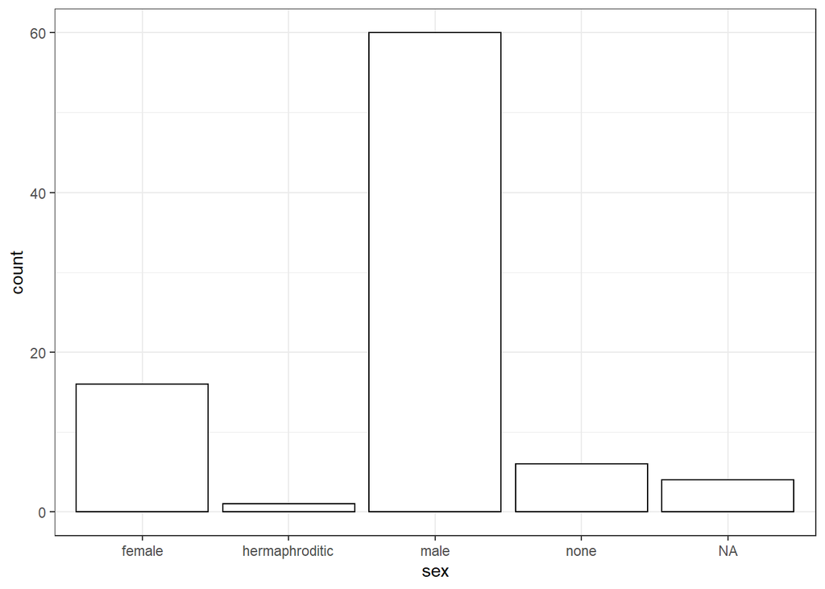

```r
starwars %>%
  ggplot(data = ., aes(x=sex)) +
  geom_bar(stat = "count", fill = "white", color = "black")
```

Each bar represents the number of cases in the `starwars` dataset with the respective *level* of `sex`. They are ordered alphabetically except for `NA` which is treated as a separate category and comes last.

### 3.1 Basic functions

These functions serve to serve the most common issues that arise when attempting to change the order of the levels of a factor. In general, they’re used in combination with `dplyr::mutate()` because the values of the factor need to be accessed.

#### fct_relevel()

With this function you can manually reorder the levels of a factor variable. We do not have to list all levels of the factor variable in `fct_relevel()` as the remaining levels are added alphabetically. Below I put the levels `female` and `male` in the first and second position of `sex`.

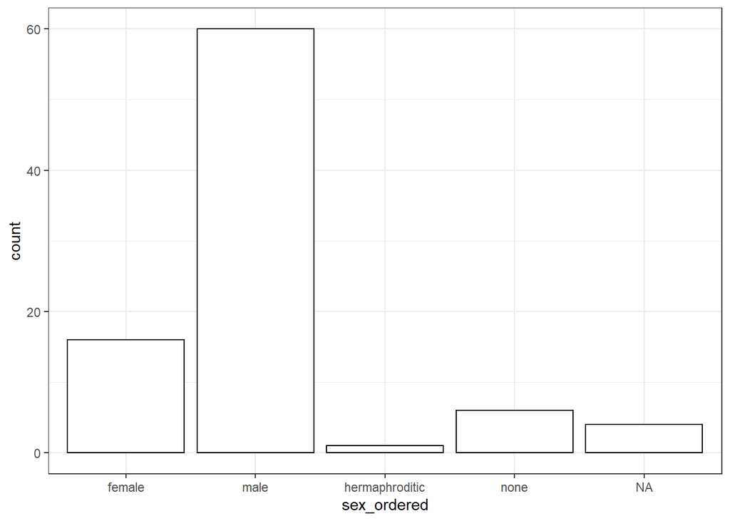

```r
starwars %>%
  mutate(sex_ordered = fct_relevel(sex, c("female", "male"))) %>%
  ggplot(data = ., aes(x = sex_ordered)) +
  geom_bar(stat = "count", fill = "white", color = "black")
```

#### fct_infreq()

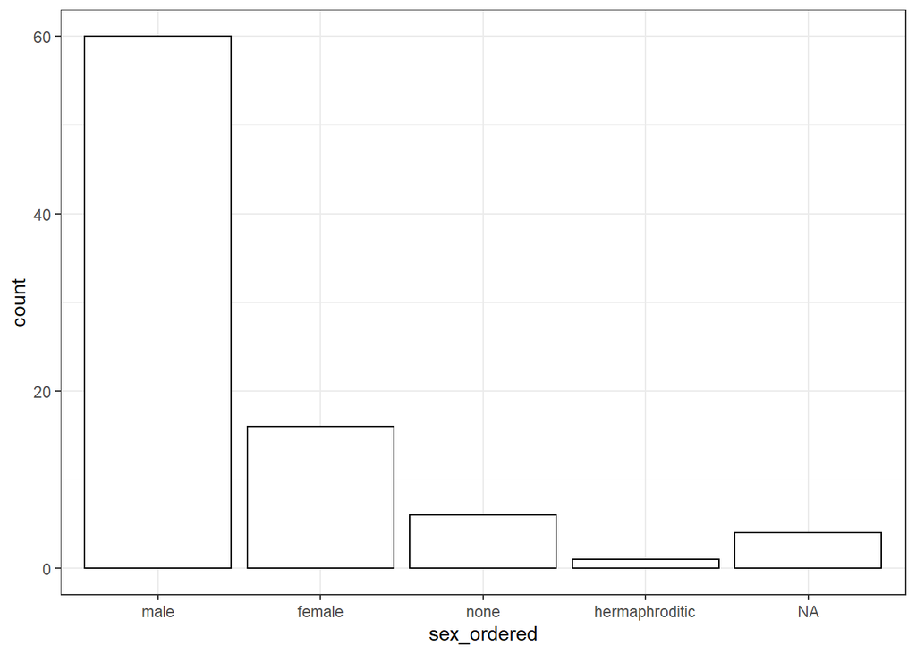

```r
starwars %>%
  mutate(sex_ordered = fct_infreq(f = sex)) %>%
  ggplot(data = ., aes(x = sex_ordered)) +
  geom_bar(stat = "count", fill = "white", color = "black")
```

#### fct_inseq()

There is also a related function called `fct_inseq()` which is designed to work with factors whose levels display a *numeric sequence*. Columns of type *numeric* such as `birth_year` must always be explicitly converted to factor.

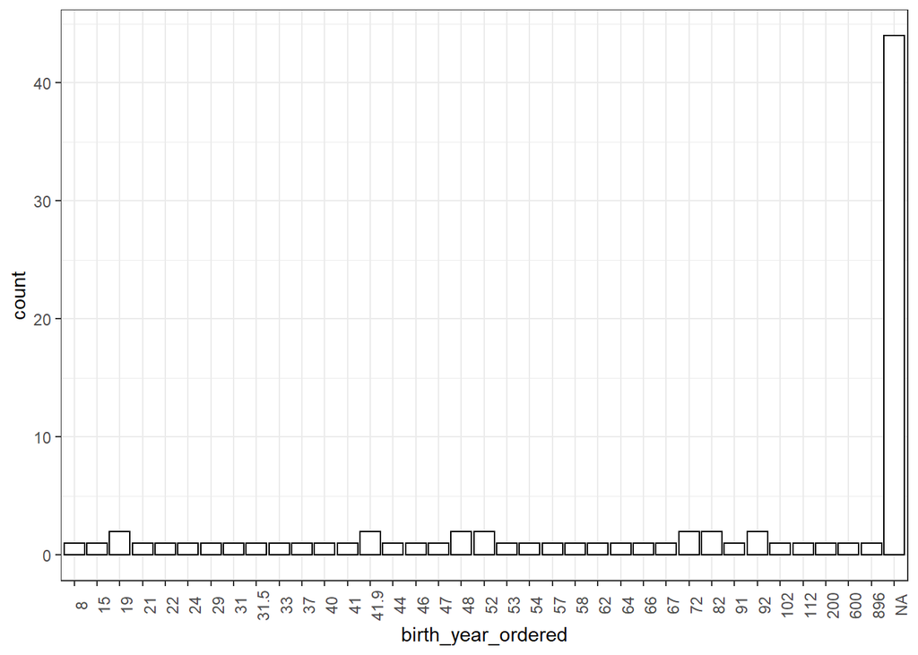

```r
starwars %>%
  mutate(birth_year_ordered = fct_inseq(as.factor(birth_year))) %>%
  ggplot(data = ., aes(x = birth_year_ordered)) +
  geom_bar(stat = "count", fill = "white", color = "black") +
  theme(axis.text.x = element_text(angle = 90))
```

#### fct_inorder()

For what it’s worth you can also reorder the levels of a factor by the order in which they are sorted in the dataset.

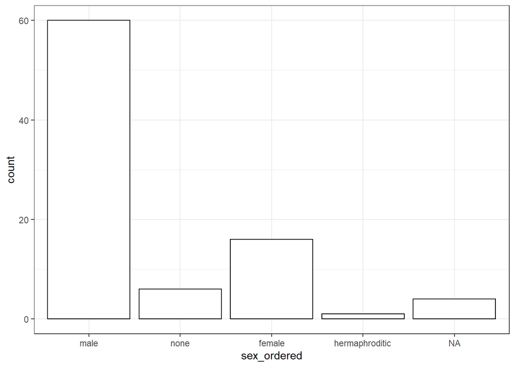

```r
starwars %>%
  mutate(sex_ordered = fct_inorder(sex)) %>%
  ggplot(data = ., aes(x = sex_ordered)) +
  geom_bar(stat = "count", fill = "white", color = "black")
```

Let’s have a look at the first 10 rows of the `starwars` dataset to verify this.

```r
starwars %>%
  print()
```

```
## # A tibble: 87 x 14
##    name     height  mass hair_color skin_color eye_color birth_year sex   gender
##    <chr>     <int> <dbl> <chr>      <chr>      <chr>          <dbl> <chr> <chr>
##  1 Luke Sk~    172    77 blond      fair       blue            19   male  mascu~
##  2 C-3PO       167    75 <NA>       gold       yellow         112   none  mascu~
##  3 R2-D2        96    32 <NA>       white, bl~ red             33   none  mascu~
##  4 Darth V~    202   136 none       white      yellow          41.9 male  mascu~
##  5 Leia Or~    150    49 brown      light      brown           19   fema~ femin~
##  6 Owen La~    178   120 brown, gr~ light      blue            52   male  mascu~
##  7 Beru Wh~    165    75 brown      light      blue            47   fema~ femin~
##  8 R5-D4        97    32 <NA>       white, red red             NA   none  mascu~
##  9 Biggs D~    183    84 black      light      brown           24   male  mascu~
## 10 Obi-Wan~    182    77 auburn, w~ fair       blue-gray       57   male  mascu~
## # ... with 77 more rows, and 5 more variables: homeworld <chr>, species <chr>,
## #   films <list>, vehicles <list>, starships <list>
```

#### fct_rev()

This function *reverses* the order the factor’s levels. This can be useful when changing the axes of a bar chart with function `ggplot2::coord_flip()`. When applying `fct_rev()` the levels of the factor appear alphabetically from the top to the bottom of the y-axis instead the other way around (as always except for `NA`).

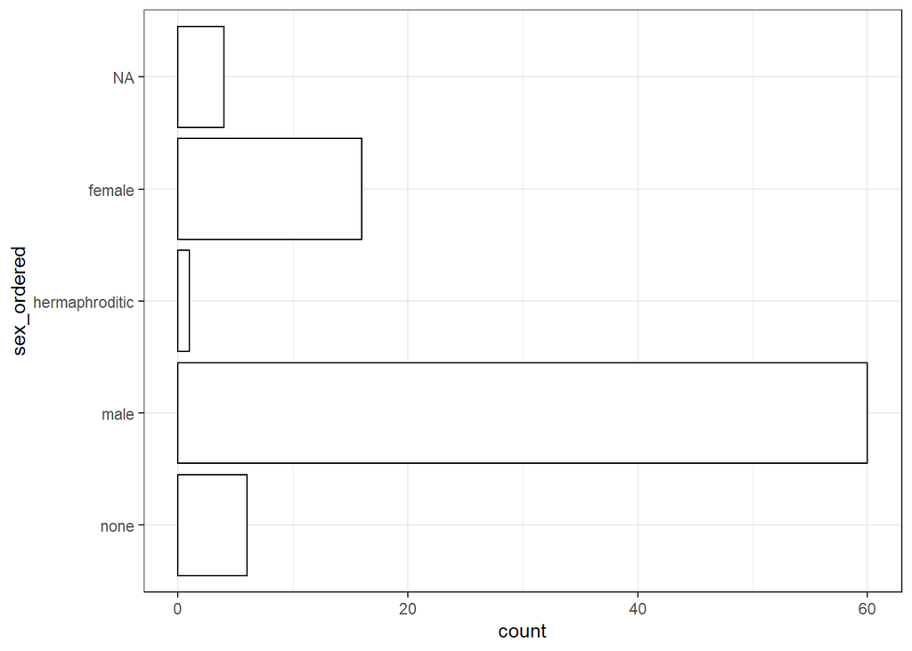

```r
starwars %>%
  mutate(sex_ordered = fct_rev(f = sex)) %>%
  ggplot(data = ., aes(x = sex_ordered)) +
  geom_bar(stat = "count", fill = "white", color = "black") +
  coord_flip()
```

### 3.2 Advanced functions

There are also some more advanced functions which you’ll either use less frequent or which require more thought when applying them.

#### fct_shift()

You can shift the levels of a factor to the left or right with this function. Positive values of argument `n =` shift the levels to the left and negative values to the right.

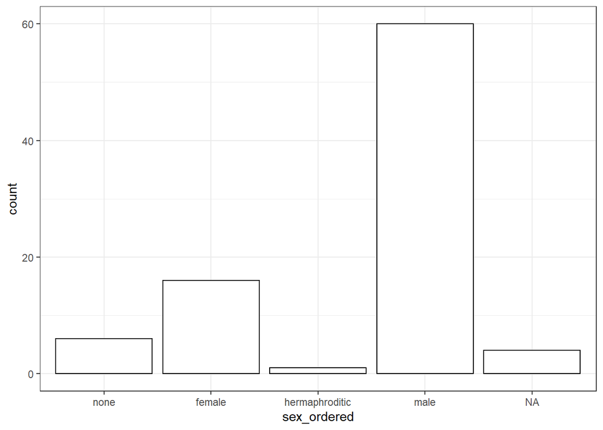

```r
starwars %>%
  mutate(sex_ordered = fct_shift(f = as.factor(sex), n = -1)) %>%
  ggplot(data = ., aes(x = sex_ordered)) +
  geom_bar(stat = "count", fill = "white", color = "black")
```

#### fct_shuffle()

With `fct_shuffle()` you can randomly permute the order of a factor’s levels. Use `set.seed()` to obtain replicable results when working with random function components.

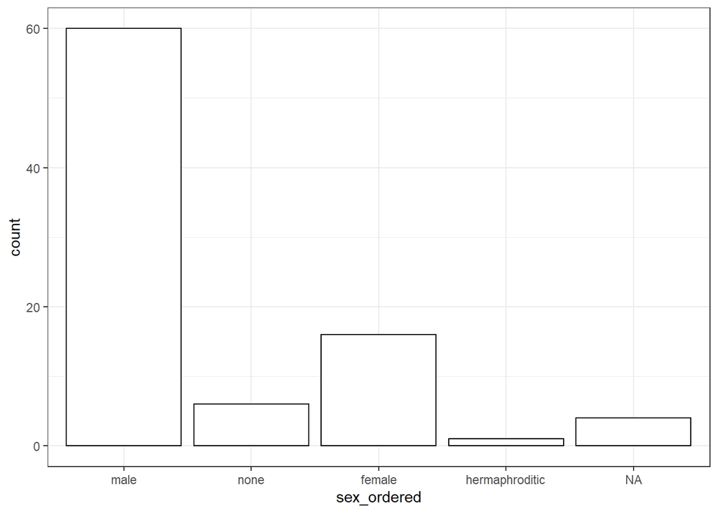

```r
set.seed(123)
starwars %>%
  mutate(sex_ordered = fct_shuffle(f = sex)) %>%
  ggplot(data = ., aes(x = sex_ordered)) +
  geom_bar(stat = "count", fill = "white", color = "black")
```

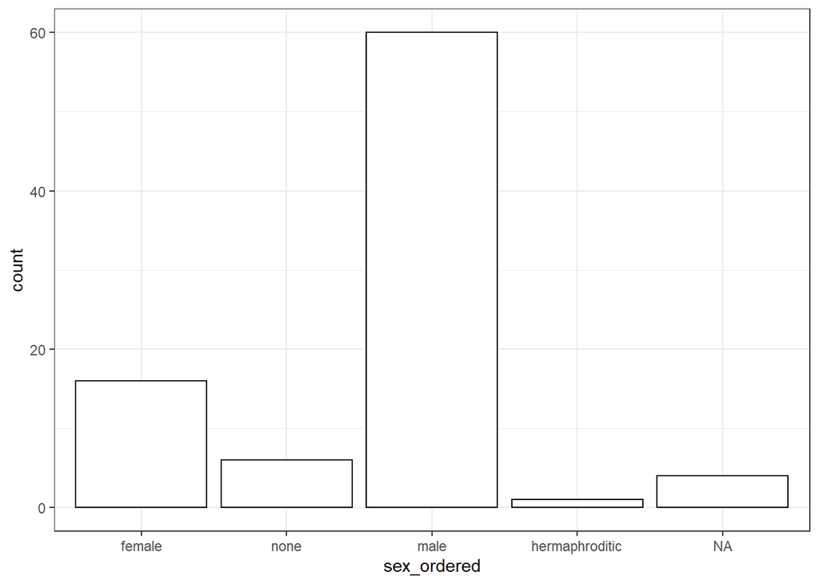

```r
set.seed(456)
starwars %>%
  mutate(sex_ordered = fct_shuffle(f = sex)) %>%
  ggplot(data = ., aes(x = sex_ordered)) +
  geom_bar(stat = "count", fill = "white", color = "black")
```

#### fct_reorder()

The function `fct_reorder()` lets you reorder a factor’s levels by their relationship with another variable. This is useful when plotting a factor and rearrange its levels by another column. Below I want to sort the levels of column `sex` according to the average height of the Star Wars characters within each unique value (level) of `sex`. In addition to the factor `.f =` we have to specify the variable along which the reordering should be carried out `.x =`, as well as a function `.fun =`. determining the reordering. With argument `.desc =` we can force a descending order.

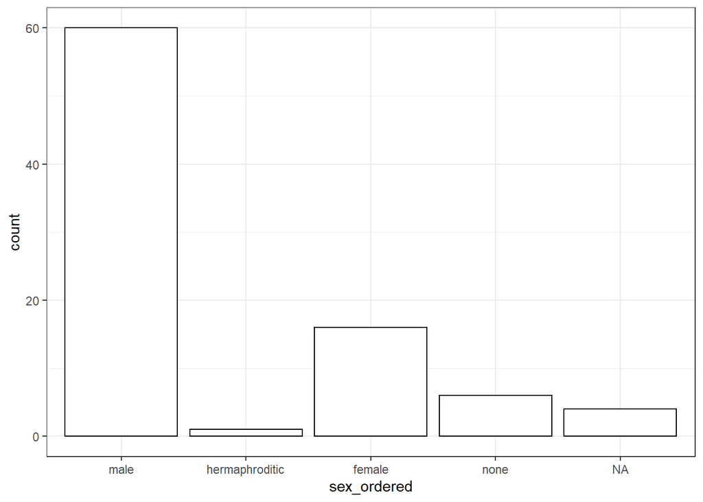

```r
starwars %>%
  mutate(sex_ordered =
           fct_reorder(
             .f = sex,
             .x = height,
             .fun = mean, na.rm=T,
             .desc = TRUE)
         ) %>%
  ggplot(data = ., aes(x = sex_ordered)) +
  geom_bar(stat = "count", fill = "white", color = "black")
```

```r
starwars %>%
  group_by(sex) %>%
  summarise(mean_height = mean(height, na.rm = TRUE)) %>%
  arrange(desc(mean_height))
```

```
## # A tibble: 5 x 2
##   sex            mean_height
##   <chr>                <dbl>
## 1 <NA>                  181.
## 2 male                  179.
## 3 hermaphroditic        175
## 4 female                169.
## 5 none                  131.
```

#### Digression: fct_reorder2()

This is a 2d version of the function `fct_reorder()` and lets you specify two variables (`.x =`, `.y =` among which the factor’s levels are reordered. However, only two functions might be used with argument `.fun =`. The function `last2()` finds the last value of .y when sorted by .x and `first2()` finds the first value. This is helpful when using a line plot and aligning the line colours with the legend.

Have a look at the plot below. The legend is quite hard to read isn’t it?

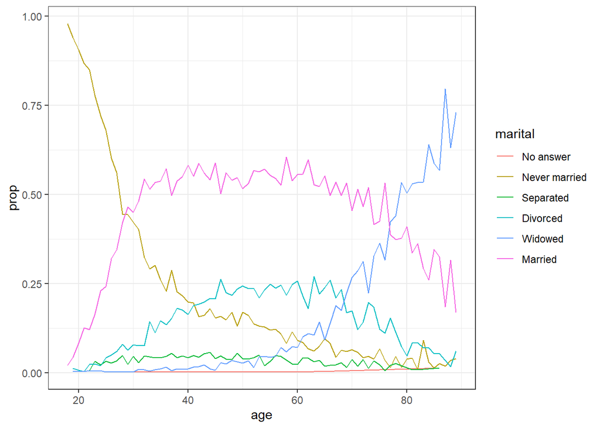

```r
by_age <- gss_cat %>%
  filter(!is.na(age)) %>%
  count(age, marital) %>%
  group_by(age) %>%
  mutate(prop = n / sum(n))

ggplot(by_age, aes(age, prop, colour = marital)) +
  geom_line(na.rm = TRUE)
```

Now we’ll use `fct_reorder()2` to improve the plot.

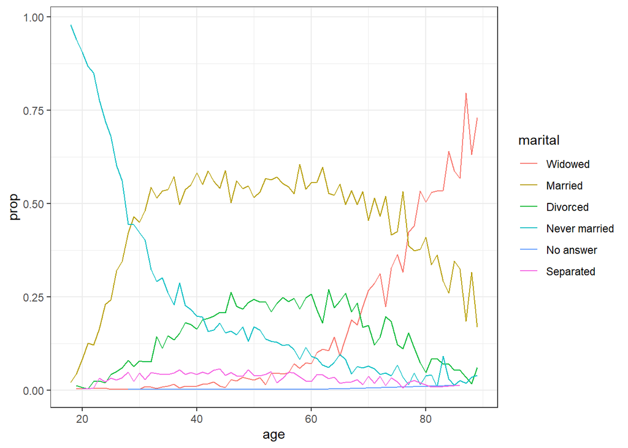

```r
ggplot(data = by_age,
       aes(x = age, y = prop,
           colour = fct_reorder2(.f = marital, .x = age, .y = prop, .fun = last2)
           )
       ) +
  geom_line() +
  labs(colour = "marital")
```

## 4. Change the value of levels

Again you’ll often use the functions in this sections to alter the values of the factor, hence I demonstrate the examples in combination with function `dplyr::mutate()`.

### fct_recode()

The function `fct_recode()` lets us manually change levels of a factor. You only have to specify a new value of the level for each original value that you want to change. If no value is supplied for an original level, the level remains unaltered. Below I’m recoding the levels of column `sex` such that only the first letter of each original level is present in the new factor `sex_mod`.

```r
starwars %>%
  mutate(sex_mod = fct_recode(
    sex,
    m = "male",f = "female",
    n = "none", h = "hermaphroditic")
    ) %>%
  select(name, sex_mod, sex)
```

```
## # A tibble: 87 x 3
##    name               sex_mod sex
##    <chr>              <fct>   <chr>
##  1 Luke Skywalker     m       male
##  2 C-3PO              n       none
##  3 R2-D2              n       none
##  4 Darth Vader        m       male
##  5 Leia Organa        f       female
##  6 Owen Lars          m       male
##  7 Beru Whitesun lars f       female
##  8 R5-D4              n       none
##  9 Biggs Darklighter  m       male
## 10 Obi-Wan Kenobi     m       male
## # ... with 77 more rows
```

### fct_relabel()

Also consider using the function `fct_relabel()` which obeys the `purrr::map()` syntax to apply a function or expression to each level. Below I use function `paste0()` to add the string `sex_` to each level of variable `sex`.

```r
starwars %>%
  mutate(sex_mod = fct_relabel(
    sex,
    ~ paste0("sex_", .x))
    ) %>%
  select(name, sex_mod, sex)
```

```
## # A tibble: 87 x 3
##    name               sex_mod    sex
##    <chr>              <fct>      <chr>
##  1 Luke Skywalker     sex_male   male
##  2 C-3PO              sex_none   none
##  3 R2-D2              sex_none   none
##  4 Darth Vader        sex_male   male
##  5 Leia Organa        sex_female female
##  6 Owen Lars          sex_male   male
##  7 Beru Whitesun lars sex_female female
##  8 R5-D4              sex_none   none
##  9 Biggs Darklighter  sex_male   male
## 10 Obi-Wan Kenobi     sex_male   male
## # ... with 77 more rows
```

### fct_anon()

Sometimes, for example when publishing sensitive data, it may become necessary to anonymize levels of a factor variable with random integers. This can be done with function `fct_anon()`.

```r
starwars %>%
  mutate(sex_mod = fct_anon(as.factor(sex))) %>%
  select(name, sex_mod, sex)
```

```
## # A tibble: 87 x 3
##    name               sex_mod sex
##    <chr>              <fct>   <chr>
##  1 Luke Skywalker     4       male
##  2 C-3PO              2       none
##  3 R2-D2              2       none
##  4 Darth Vader        4       male
##  5 Leia Organa        1       female
##  6 Owen Lars          4       male
##  7 Beru Whitesun lars 1       female
##  8 R5-D4              2       none
##  9 Biggs Darklighter  4       male
## 10 Obi-Wan Kenobi     4       male
## # ... with 77 more rows
```

It is also possible to add a `prefix =` to the anonymized factor.

```r
starwars %>%
  mutate(sex_mod =
           fct_anon(
             as.factor(sex),
             prefix = "sex_"
             )
         ) %>%
  select(name, sex_mod, sex)
```

```
## # A tibble: 87 x 3
##    name               sex_mod sex
##    <chr>              <fct>   <chr>
##  1 Luke Skywalker     sex_1   male
##  2 C-3PO              sex_4   none
##  3 R2-D2              sex_4   none
##  4 Darth Vader        sex_1   male
##  5 Leia Organa        sex_3   female
##  6 Owen Lars          sex_1   male
##  7 Beru Whitesun lars sex_3   female
##  8 R5-D4              sex_4   none
##  9 Biggs Darklighter  sex_1   male
## 10 Obi-Wan Kenobi     sex_1   male
## # ... with 77 more rows
```

### fct_collapse()

With the function `fct_collapse()` we can collapse levels of a factor into manually defined groups. This is very useful when a factor has too many distinct levels but some of them share common characteristics and you can mingle them together. Below I’m generating new levels for column `hair_color`. Star Wars characters with unicolored/multicolored hair are reassigned either the level `"singleColor"` or `"multiColor"`. Cases with `"unknown"` or `"none"` hair color are changed to `"missing"`.

```r
starwars %>%
  mutate(hair_color_mod =
           fct_collapse(
             hair_color,
             missing = c("unknown", "none"),
             singleColor = c("auburn", "black", "blond", "blonde",
                        "brown", "grey", "white"),
             multiColor = c("auburn, grey", "auburn, white", "brown, grey")
             )
         ) %>%
  select(name, hair_color_mod, hair_color)
```

```
## # A tibble: 87 x 3
##    name               hair_color_mod hair_color
##    <chr>              <fct>          <chr>
##  1 Luke Skywalker     singleColor    blond
##  2 C-3PO              <NA>           <NA>
##  3 R2-D2              <NA>           <NA>
##  4 Darth Vader        missing        none
##  5 Leia Organa        singleColor    brown
##  6 Owen Lars          multiColor     brown, grey
##  7 Beru Whitesun lars singleColor    brown
##  8 R5-D4              <NA>           <NA>
##  9 Biggs Darklighter  singleColor    black
## 10 Obi-Wan Kenobi     multiColor     auburn, white
## # ... with 77 more rows
```

### fct_other()

The function `fct_other()` is used to replace levels of a factor with value `"Other"`. We can use this function either with argument `keep =` or `drop =`.

The argument `keep =` merges all **not supplied** levels into the new category `"Other"`.

```r
starwars %>%
  mutate(sex_mod =
           fct_other(
             sex,
             keep = c("male", "female")
             )
         ) %>%
  select(name, sex_mod, sex)
```

```
## # A tibble: 87 x 3
##    name               sex_mod sex
##    <chr>              <fct>   <chr>
##  1 Luke Skywalker     male    male
##  2 C-3PO              Other   none
##  3 R2-D2              Other   none
##  4 Darth Vader        male    male
##  5 Leia Organa        female  female
##  6 Owen Lars          male    male
##  7 Beru Whitesun lars female  female
##  8 R5-D4              Other   none
##  9 Biggs Darklighter  male    male
## 10 Obi-Wan Kenobi     male    male
## # ... with 77 more rows
```

The argument `drop =` merges all **supplied** levels into the new category `"Other"`.

```r
starwars %>%
  mutate(sex_mod =
           fct_other(
             sex,
             drop = c("hermaphroditic", "none")
             )
         ) %>%
  select(name, sex_mod, sex)
```

```
## # A tibble: 87 x 3
##    name               sex_mod sex
##    <chr>              <fct>   <chr>
##  1 Luke Skywalker     male    male
##  2 C-3PO              Other   none
##  3 R2-D2              Other   none
##  4 Darth Vader        male    male
##  5 Leia Organa        female  female
##  6 Owen Lars          male    male
##  7 Beru Whitesun lars female  female
##  8 R5-D4              Other   none
##  9 Biggs Darklighter  male    male
## 10 Obi-Wan Kenobi     male    male
## # ... with 77 more rows
```

### Lumping

To **lump** values of a factor’s levels means to combine them in a new level `"Other"`. Four different functions exist to do this. Mind that `NA` is not affected.

The function `fct_lump_min()` sets a `min =` number of times the value must appear - otherwise it is reassigned to `"Other"`.

```r
starwars %>%
  mutate(sex_lumped = fct_lump_min(sex, min = 7)) %>%
  count(sex_lumped, sex)
```

```
## # A tibble: 5 x 3
##   sex_lumped sex                n
##   <fct>      <chr>          <int>
## 1 female     female            16
## 2 male       male              60
## 3 Other      hermaphroditic     1
## 4 Other      none               6
## 5 <NA>       <NA>               4
```

All levels of a factor except for the `n =` most frequent ones can be lumped with function `fct_lump_n()`. This also works in the other direction (least frequent) with negative values of *n*.

```r
starwars %>%
  mutate(sex_lumped = fct_lump_n(sex, n = 2)) %>%
  count(sex_lumped, sex)
```

```
## # A tibble: 5 x 3
##   sex_lumped sex                n
##   <fct>      <chr>          <int>
## 1 female     female            16
## 2 male       male              60
## 3 Other      hermaphroditic     1
## 4 Other      none               6
## 5 <NA>       <NA>               4
```

To lump levels of a factor that appear less than a relative proportion of cases use the function `fct_lump_prop()`.

```r
starwars %>%
  mutate(sex_lumped = fct_lump_prop(sex, prop = 0.20)) %>%
  count(sex_lumped, sex)
```

```
## # A tibble: 5 x 3
##   sex_lumped sex                n
##   <fct>      <chr>          <int>
## 1 male       male              60
## 2 Other      female            16
## 3 Other      hermaphroditic     1
## 4 Other      none               6
## 5 <NA>       <NA>               4
```

Last but not least the function `fct_lump_lowfreq()` can be used to lump together the least frequent levels of a factor, which ensures that `"other"` is still the smallest level.

```r
starwars %>%
  mutate(sex_lumped = fct_lump_lowfreq(sex)) %>%
  count(sex_lumped, sex)
```

```
## # A tibble: 5 x 3
##   sex_lumped sex                n
##   <fct>      <chr>          <int>
## 1 male       male              60
## 2 Other      female            16
## 3 Other      hermaphroditic     1
## 4 Other      none               6
## 5 <NA>       <NA>               4
```

## 5. Add or drop levels

The last section of this tutorial is about manipulating the **levels** of a factor instead of its values.

### fct_drop()

The function `fct_drop()` lets you *drop unused levels from a factor*. Imagine we want to create a subset of the `starwars` dataset that only contains `"Human"` characters. I call this dataset `starwars_humans`, convert the column `sex` to a factor and `dplyr::filter()` the relevant cases.

```r
starwars_humans <-
  starwars %>%
  mutate(sex = as.factor(sex)) %>%
  filter(species == "Human")
```

Let’s have a look at the `sex` of the remaining characters.

```r
starwars_humans %>% count(sex)
```

```
## # A tibble: 2 x 2
##   sex        n
##   <fct>  <int>
## 1 female     9
## 2 male      26
```

Therea are 26 *male* and 9 *female* Star Wars characters in this subset. Now, let’s also have a look at the levels of factor `sex`.

```r
starwars_humans %>% pull(sex) %>% levels()
```

```
## [1] "female"         "hermaphroditic" "male"           "none"
```

Did you expect that the factor `sex` still contains all its inital levels but which are no longer present in the subset? With function `fct_drop()` we can fix this.

```r
starwars_humans %>% pull(sex) %>% fct_drop() %>% levels()
```

```
## [1] "female" "male"
```

### fct_expand()

With this function we can *add levels to a factor*. Below I’m adding the level `"other"` to the existing levels of `sex`.

```r
starwars %>% pull(sex) %>% fct_expand("other") %>% levels()
```

```
## [1] "female"         "hermaphroditic" "male"           "none"
## [5] "other"
```

Mind that the Star Wars characters’ values of `sex` are not affected by this function.

### fct_explicit_na()

To assign a level to `NA` values of a factor the function `fct_explicit_na()` can be used. By default the argument `na_level =` reassigns `NA` values to `"(Missing)"`, which is then a distinct level. Let’s take a look at this by plotting the bar chart with the Star Wars characters’ `sex` again!

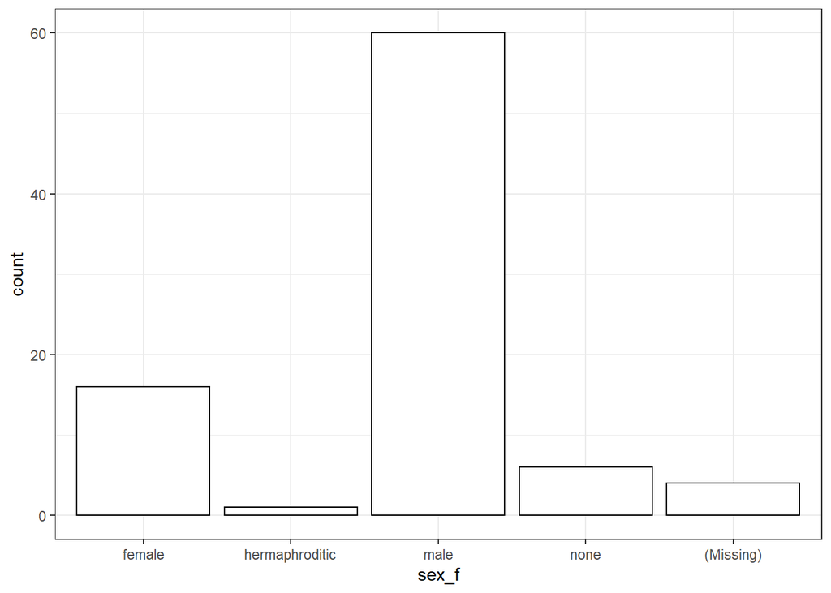

```r
starwars %>%
  mutate(sex_f = fct_explicit_na(sex, na_level = "(Missing)")) %>%
  ggplot(data = ., aes(x = sex_f)) +
  geom_bar(stat = "count", fill = "white", color = "black")
```

Also let us compare the levels of factor `sex` before…

```r
starwars %>% mutate(sex = as.factor(sex)) %>% pull(sex) %>% levels()
```

```
## [1] "female"         "hermaphroditic" "male"           "none"
```

…and after applying `fct_explicit_na()`.

```r
starwars %>%
  mutate(sex_f = fct_explicit_na(sex, na_level = "(Missing)")) %>%
  pull(sex_f) %>% levels()
```

```
## [1] "female"         "hermaphroditic" "male"           "none"
## [5] "(Missing)"
```

## References

Wickham, Hadley. 2020. *Forcats: Tools for Working with Categorical Variables (factors)*. https://CRAN.R-project.org/package=forcats.